# Carbon Fibre Precursor Development

Jasjeet Kaur

Fibre Innovation and Composites, CSIRO Manufacturing

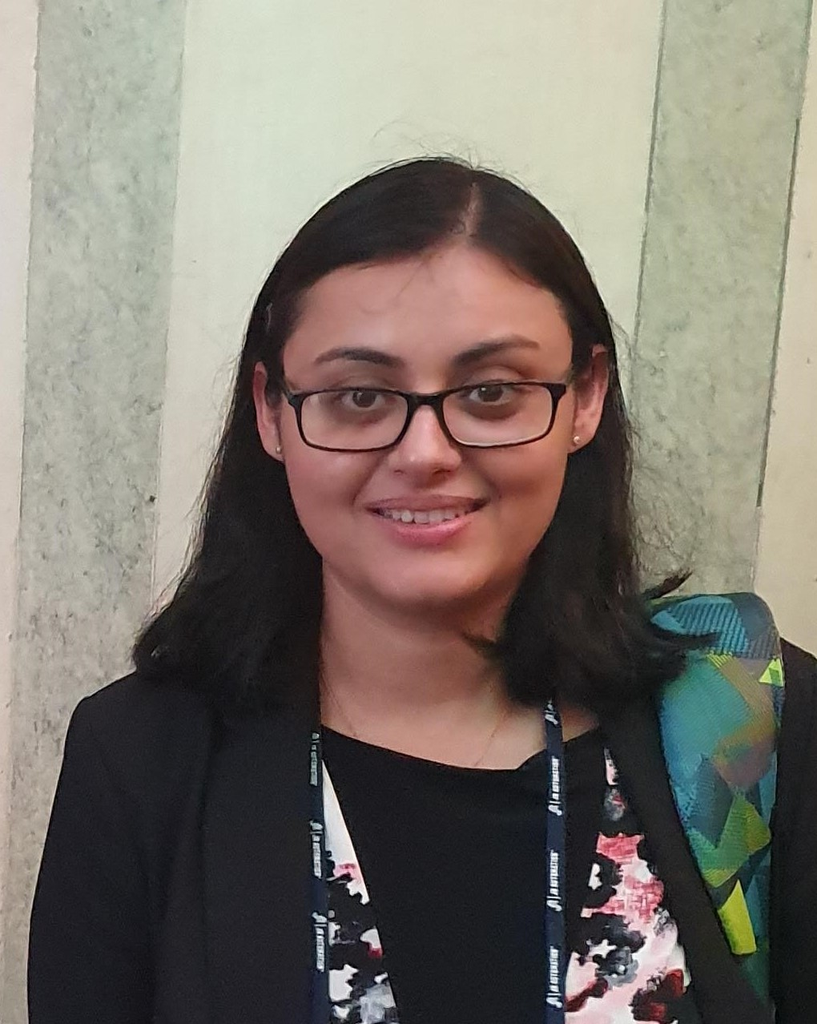

# Introduction

I am a Research Scientist in **Carbon Fibre Precursor development**. I did not know how to code prior to **Data School Focus** but was always curious to learn. My daily routine included designing and performing experiments followed by processing data and its analysis using *Origin* and *Microsoft Excel*. I work on a pilot scale wet spinning line which turns novel polymers into fibres and involves many predictor variables for optimisation. Large amount of data is generated from testing the fibres which makes analysis a tedious and time consuming task and a lag in feeding complete learnings of one experiment to the next.

# My Project

I am developing high quality precursors from novel polymers to produce advanced carbon fibres for aerospace and automotives. Carbon fibre manufacturing consists of three steps:

- Synthesis of polymers
- Spinning of polymer solutions into precursor fibres
- Conversion of precursor fibres into carbon fibres

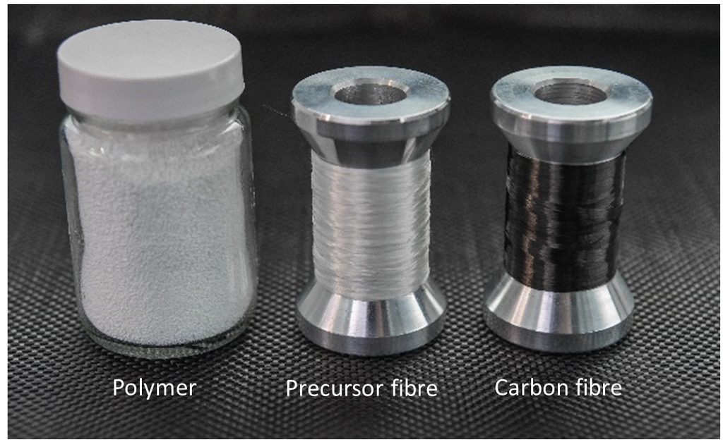

The final carbon fibre produced is influenced by all the variables involved in the above three steps. This makes optimisation very complex. Understanding evolution of fibre characteristics at every step along the process is important. But analysis of the collected data becomes a cumbersome task. My goal through Data School Focus is to become efficient in tidying and visualising data. My project goal is to find out the processing conditions to produce **strongest and stiffest carbon fibre** and understand the influence of each treatment zone.

# Experimental

My data was collected from 14 experiments performed on a commercial precursor using pilot scale carbon fibre production line. There are two main processes in manufacture of carbon fibre: oxidation and carbonisation. There are four zones in the oxidation step, namely Zone 1, Zone 2, Zone 3, Zone 4 and two zones in the carbonisation step namely LT (low temperature) and HT (high temperature). The fibres were collected after each treatment zone and also at the end of the processing. I have only used a subset of my data for this poster. In the first subset, 3 experiments were chosen that varied in speed of processing line. The 3 speeds were 14 (experiment 1), 22 (experiment 2) and 30 (experiment 3) in metre/hour. The fibres were tested from each zone in the oxidation and carbonisation process using ‘Favimat’ which is a single fibre tester. The final carbon fibre was also tested using a bundle test namely tow. The predictor variables in the data were *speed, temperature, zones, tension*. The response variables in the data were *strength, stiffness, diameter, elongation*. Table 1 shows the predictor and response variables used in my experiments.

```r
Tidy_table <- Jilin_carbonisation_data_july2019 %>%
 select(Experiment, Fibre, Line_speed, Zones, Diameter, Tenacity, Ini.Mod)
  Tidy_table$Diameter<-as.numeric(Tidy_table$Diameter)
  Tidy_table$Tenacity<-as.numeric(Tidy_table$Tenacity)
  Tidy_table$Ini.Mod<-as.numeric(Tidy_table$Ini.Mod)
knitr::kable(head (Tidy_table), format = "html", digits = 2, caption = "Predictor and response variables in the experiments") %>%
kable_styling("striped")
```

Table 1: Predictor and response variables in the experiments

| Experiment | Fibre | Line_speed | Zones | Diameter | Tenacity | Ini.Mod |
| --- | --- | --- | --- | --- | --- | --- |
| NA | NA | metre/hour | NA | NA | NA | NA |
| 1 | Jilin | 14 | Zone 1 | 11.50 | 3.79 | 109.61 |
| 1 | Jilin | 14 | Zone 1 | 11.44 | 4.25 | 109.87 |
| 1 | Jilin | 14 | Zone 1 | 11.45 | 4.11 | 109.68 |
| 1 | Jilin | 14 | Zone 1 | 11.75 | 3.96 | 106.54 |
| 1 | Jilin | 14 | Zone 1 | 11.63 | 3.91 | 106.14 |

# Preliminary results and discussion

It can be seen from Figure 3 that there doesn’t appear to be any difference in the strength of final carbon fibre due to change in the processing speeds. But when we look at Figure 1 there does appear to be difference in fibre properties when fibre evolves through oxidation process. This difference is even more obvious in Figure 2 which is a measurement of fibre stiffness. So these visualisations of raw data helped to understand that there is a difference in the mechanical properties of the fibre in the oxidation process but this effect doesn not seem to have translated in the carbonisation process. This may inform that the conditions used for low temperature carbonisation are not optimised and need to be investigated further.

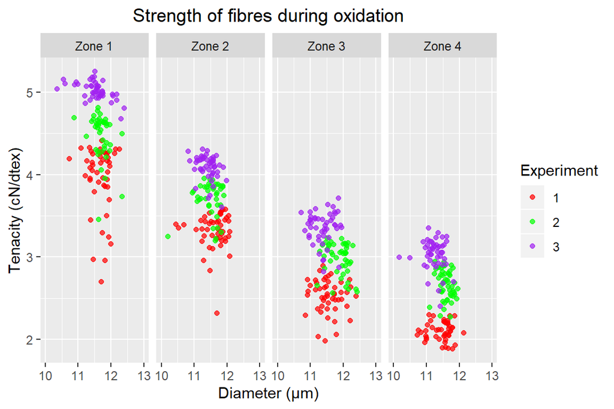

Figure 1: Effect of processing speed on tenacity and diameter of oxidised fibres

```r
# Filtering only a subset of data where line speed was changed and for only four zones in the oxidation process
Experiment_a <- Jilin_carbonisation_data_july2019 %>%
  filter(Experiment %in% c(1,2,3)) %>%
  filter(Zones %in% c("Zone 1","Zone 2","Zone 3", "Zone 4"))
# Converting characters into numeric and factors
Experiment_a$Zones<-as.factor(Experiment_a$Zones)
Experiment_a$Tenacity<- as.numeric(Experiment_a$Tenacity)
Experiment_a$Diameter <- as.numeric(Experiment_a$Diameter)
Experiment_a$Experiment<-as.factor(Experiment_a$Experiment)
Experiment_a$Emax <- as.numeric(Experiment_a$Emax)
Experiment_a$Ini.Modul <- as.numeric(Experiment_a$Ini.Modul)
Experiment_a$Ini.Mod <- as.numeric(Experiment_a$Ini.Mod)
# Relevel zones to get required sequence in legend
Experiment_b <- Experiment_a%>%
  mutate(Zones=fct_relevel(Zones,"Zone 1","Zone 2","Zone 3", "Zone 4"))
# Visualisation using ggplot2
Line_speed_plot1 <- ggplot(data=Experiment_b,mapping = aes(x = Diameter, y = Tenacity , colour = Experiment)) +
  geom_point(alpha = 0.7) + scale_colour_manual(values = c("red","green","purple"))  + ylab("Tenacity (cN/dtex)") + xlab("Diameter (µm)") + xlim(10,13) + facet_grid(~ Zones, scales = ("fixed")) + labs(title = "Strength of fibres during oxidation") + theme(plot.title = element_text(hjust = 0.5))
Line_speed_plot1
```

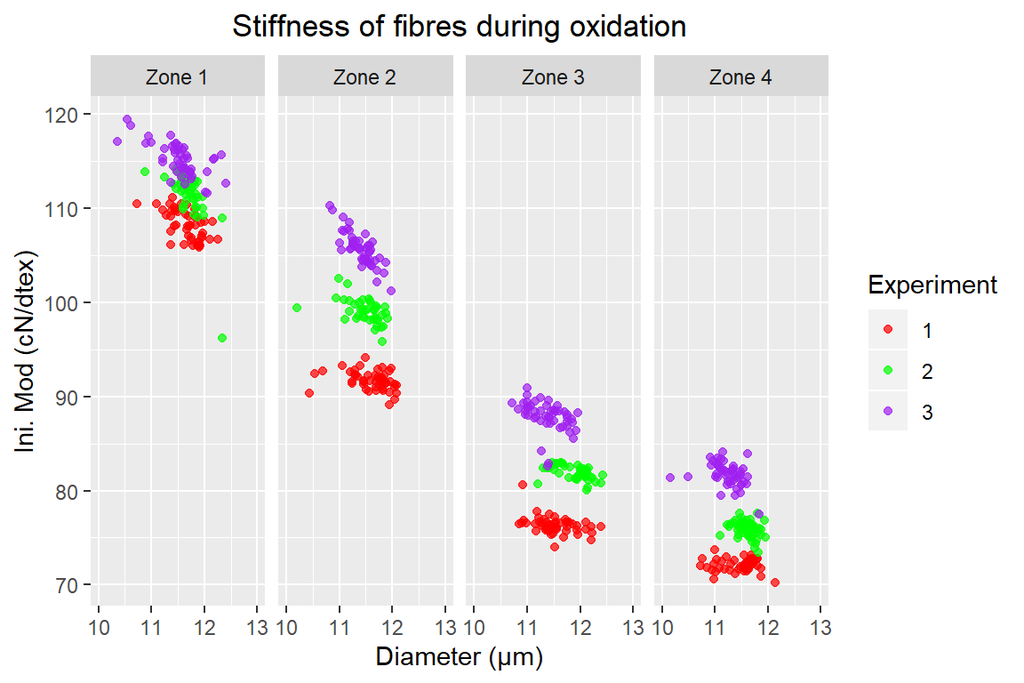

Figure 2: Effect of processing speed on initial modulus and diameter of oxidised fibres

```r
# Plot of initial modulus/fibre stiffness in oxidation zones
Line_speed_plot2 <- ggplot(data=Experiment_b,mapping = aes(x = Diameter, y = Ini.Mod , colour = Experiment)) +
  geom_point(alpha = 0.7) + scale_colour_manual(values = c("red","green","purple"))  + ylab("Ini. Mod (cN/dtex)") + xlab("Diameter (µm)") + xlim(10,13) + facet_grid(~ Zones, scales = ("fixed")) + labs(title = "Stiffness of fibres during oxidation") + theme(plot.title = element_text(hjust = 0.5))
Line_speed_plot2
```

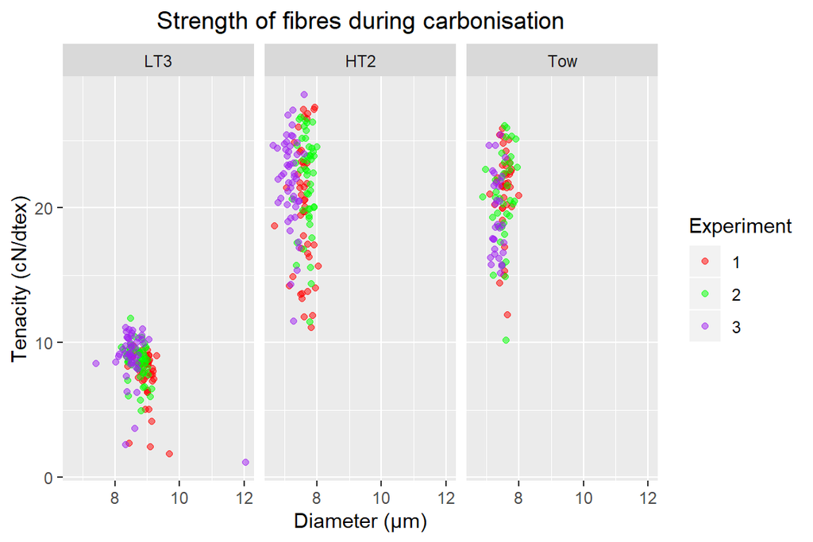

Figure 3: Effect of processing speed on tenacity and diameter of carbon fibres

```r
# Filtering data for low temp and high temp carbonisation and after tow testing
Experiment_c <- Jilin_carbonisation_data_july2019 %>%
  filter(Experiment %in% c(1,2,3)) %>%
  filter(Zones %in% c("LT3","HT2", "Tow"))
#str(Experiment_c)
# Change variables from characters to numbers and factors
Experiment_c$Zones<-as.factor(Experiment_c$Zones)
Experiment_c$Tenacity<- as.numeric(Experiment_c$Tenacity)
Experiment_c$Diameter <- as.numeric(Experiment_c$Diameter)
Experiment_c$Experiment<-as.factor(Experiment_c$Experiment)
Experiment_c$Emax <- as.numeric(Experiment_c$Emax)
Experiment_c$Ini.Modul <- as.numeric(Experiment_c$Ini.Modul)
Experiment_c$Ini.Mod <- as.numeric(Experiment_c$Ini.Mod)
#str(Experiment_c)
#Relevel zones to get the sequence of legends
Experiment_d <- Experiment_c%>%
  mutate(Zones=fct_relevel(Zones,"LT3","HT2","Tow"))
#str(Experiment_d)
#Visualisation
Line_speed_plot3 <- ggplot(data=Experiment_d,mapping = aes(x = Diameter , y = Tenacity, colour = Experiment)) +
  geom_point(alpha = 0.5) + scale_colour_manual(values = c("red","green","purple"))  + ylab ("Tenacity (cN/dtex)") +  xlab("Diameter (µm)") + facet_grid(~ Zones, scales = ("fixed")) + labs(title = "Strength of fibres during carbonisation") + theme(plot.title = element_text(hjust = 0.5))
Line_speed_plot3
```

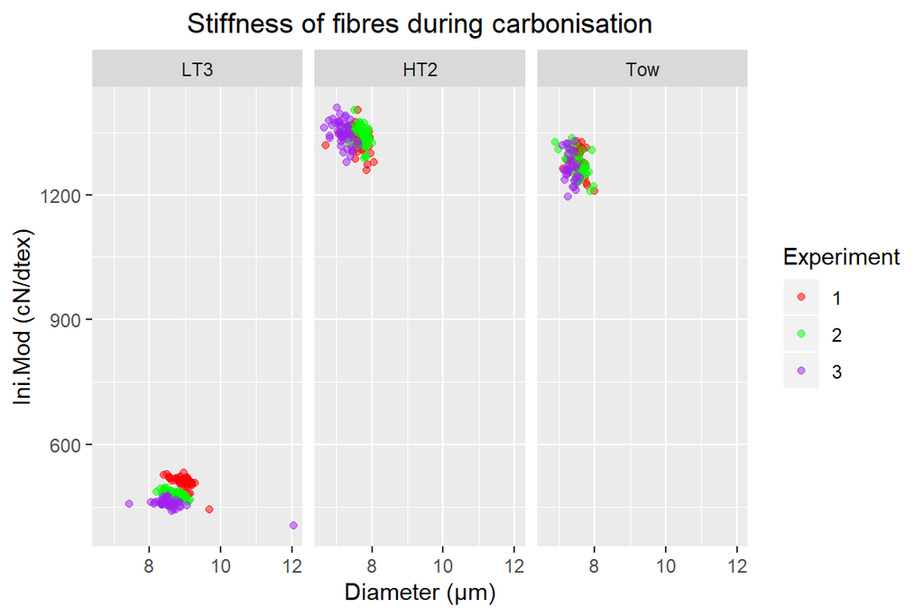

Figure 4: Effect of processing speed on initial modulus and diameter of carbon fibres

```r
Line_speed_plot4 <- ggplot(data=Experiment_d,mapping = aes(x = Diameter , y = Ini.Mod, colour = Experiment)) +
  geom_point(alpha = 0.5) + scale_colour_manual(values = c("red","green","purple"))  + ylab ("Ini.Mod (cN/dtex)") +  xlab("Diameter (µm)") + facet_grid(~ Zones, scales = ("fixed")) + labs(title = "Stiffness of fibres during carbonisation") + theme(plot.title = element_text(hjust = 0.5))
Line_speed_plot4
```

# My Digital Toolbox

- `tidyverse` for programming
- `ggplot2`for visualisation
- `Knitr` and `KableExtra` to create this html document

## Favourite tool

Some of my favourite functions are `str()`,`filter()`. I enjoyed using `ggplot2`

# My time went …

I easily sailed through the lesson days and activities but I was nervous on practical days while working on my own data set, especially when I encountered problems. The helpers and instructors were extremely knowledgable and patiently solved the queries. One of the challenge in my data set was inconsistent white space.

# Next steps

Data school has given me skills to manage my data and to be able to return to it and reuse it. I would like to polish my R skills down the track and would also like to learn Python.

# My Data School Experience

Data School Focus was a great learning experience. I enjoyed all aspects of data management including tidying, visualisation and creating a markdown document for communication. Thanks to Stephen, Kerensa, Alex and all the helpers who were extremely knowledgeable. I am excited that the skills I have learnt in Data School will allow me to think about data management from the very beginning of the project. Now I have the tools like the Research Data Planner to be able to initiate discussions with my team mates on how to have a healthy data ecosystem. Thanks to the librarians for the lesson. Having learnt some R skills now, I am not scared of large datasets. The entire Data School Cohort has been so friendly. Last but not the least, big thanks to Nat for being an amazing go to person. Thanks to my managers for giving me the opportunity to attend Data School Focus program, it was worth it. Acknowledgements to Nicole Phair Sorenson for providing the raw data used in this poster.